# Deep Learning Grundlagen - Evaluieren

[interactive chart not shown]

## **Evaluieren**

Wie gut und stabil ist mein Model?

- Performance Messen
- Test auf unbekannten Daten
- Robust gegen Änderungen
- Vergleich mit Mensch?

[interactive chart not shown]

## **Performance Messen**

- Kosten vs Accuracy
  - Kosten: Training, nicht interpretierbar
  - Accuracy: verständliches Mass der Leistung

[figure not shown]

[interactive chart not shown]

## **Performance Messen**

- Kosten vs Accuracy
  - Kosten: Training, nicht interpretierbar
  - Accuracy: verständliches Mass der Leistung
- Klassifizierung:
  - Accuracy
  - Precision & Recall

[figure not shown]

[interactive chart not shown]

[figure not shown]

## **Performance Messen**

- Kosten vs Accuracy
  - Kosten: Training, nicht interpretierbar
  - Accuracy: verständliches Mass der Leistung
- Klassifizierung:
  - Accuracy (Binäres label & Balancierte Daten)
  - Precision & Recall (Reinheit & Vollständigkeit)
  - Confusion Matrix (Interpretation)
  - F1 Score (vereint Precision & Recall)

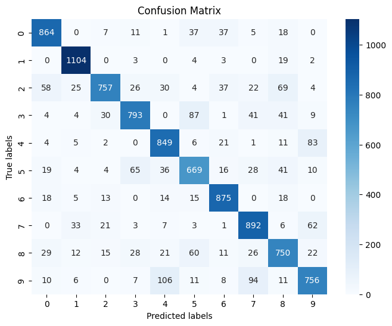

[figure not shown]

Mehr dazu [hier](https://towardsdatascience.com/various-ways-to-evaluate-a-machine-learning-models-performance-230449055f15) und [hier](https://www.jeremyjordan.me/evaluating-a-machine-learning-model/)

[figure not shown]

[interactive chart not shown]

[figure not shown]

## **Performance Messen**

- Kosten vs Accuracy
  - Kosten: Training, nicht interpretierbar
  - Accuracy: verständliches Mass der Leistung
- Klassifizierung:
  - Accuracy (Binäres label & Balancierte Daten)
  - Precision & Recall (Reinheit & Vollständigkeit)
  - Confusion Matrix (Interpretation)
  - F1 Score (vereint Precision & Recall)

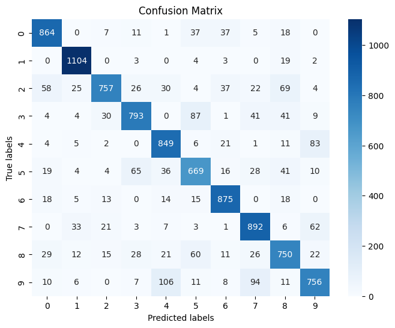

[figure not shown]

```python
from sklearn.metrics import confusion_matrix, f1_score
conf_mat = confusion_matrix(all_labels, all_preds)
f1 = f1_score(all_labels, all_preds, average='macro')
```

[figure not shown]

## **Unbekannte Daten**

- Train-Test Split
- Training mit Train, Evaluation mit Test
- Verfolge bei Training:  
  für train & test je loss & accuracy

[figure not shown]

[interactive chart not shown]

## **Robust**

- Training an verschiedenen Punkten starten

[figure not shown]

[interactive chart not shown]

## **Robust**

- Training an verschiedenen Punkten starten
- k-fold cross-validation ([mehr dazu](https://towardsdatascience.com/cross-validation-705644663568))

[figure not shown]

[interactive chart not shown]

## **Vergleich mit Mensch**

ImageNet Klassifikation

[figure not shown]

[Krizhevsky, Sutskever, Hinton 2012](https://proceedings.neurips.cc/paper_files/paper/2012/file/c399862d3b9d6b76c8436e924a68c45b-Paper.pdf)

## **Vergleich mit Mensch**

ImageNet Klassifikation

[figure not shown]

[interactive chart not shown]

[figure not shown]

## **Vergleich mit Mensch**

ImageNet Klassifikation

[figure not shown]

## Evaluieren

Hands-On: MNIST Classifier

Bearbeiten Sie [dieses Notebook](https://colab.research.google.com/drive/1a9Cg-uKiQjB5s8VKvbbRTHnPw8gihYpn?usp=sharing)

- Berechnen Sie die Konfusionsmatrix sowie den F1 score  
  auf einem beliebigen Datensatz
- Berechnen Sie diese explizit für ein untrainiertes Modell  
  auf dem Testdatensatz

Die Lösung finden Sie in [diesem Notebook](https://colab.research.google.com/drive/11teJBC7gINizTUCz0CAtPHMOZza5OOJN?usp=sharing)

[interactive chart not shown]